# Project 2_Logistic_Regression_Gaston_Alvarado

**Project 2 - Logistic Regression**

Learning Outcomes:

- Exploratory Data Analysis
- Preparing the data to train a model
- Training and making predictions using a classification model
- Modelevaluation

*Objective: The classification goal is to predict the likelihood of a liability customer buying personal loans.*

Steps and tasks:

**Attribute Information:**

- ID: Customer ID
- Age: Customer's age in completed years
- Experience: #years of professional experience
- Income: Annual income of the customer in (000)
- Zip Code: Home Address ZIP code
- Family: Family size of the customer
- CCAvg: Avg. spending on credit cards per month (000)
- Education: Education Level. 1: Undergrad; 2: Graduate; 3: Advanced/Professional
- Mortgage: Value of house mortgage if any. (000)
- Personal Loan: Did this customer accept the personal loan offered in the last campaign?
- Securities Account: Does the customer have a securities account with the bank?
- CD Account: Does the customer have a certificate of deposit (CD) account with the bank?
- Online: Does the customer use internet banking facilities?
- Credit card: Does the customer use a credit card issued by the bank?

**1.** Import the datasets and libraries, check datatype, statistical summary, shape, null values or incorrect imputation. **(5 marks)**

```python
# Import libraries

import numpy as np                    # linear algebra
import pandas as pd                   # data processing, CSV file I/O (e.g. pd.read_csv)

# Machine Learning Libraries
from sklearn.model_selection import train_test_split
from sklearn import metrics
from sklearn.linear_model import LogisticRegression
from sklearn.model_selection import GridSearchCV
from sklearn.metrics import classification_report

#Visualization libraries
import matplotlib.pyplot as plt       # matplotlib.pyplot plots data
%matplotlib inline
import seaborn as sns
import missingno as msno
from yellowbrick.classifier import ClassificationReport, ROCAUC

# Display libraries
from IPython.display import display
pd.options.display.max_columns = None
pd.options.display.float_format = '{:,.2f}'.format
```

**Visualize top of the data**

```python
data = pd.read_csv("Bank_Personal_Loan_Modelling.csv")
data.head()
```

|  | ID | Age | Experience | Income | ZIP Code | Family | CCAvg | Education | Mortgage | Personal Loan | Securities Account | CD Account | Online | CreditCard |
| --- | --- | --- | --- | --- | --- | --- | --- | --- | --- | --- | --- | --- | --- | --- |
| 0 | 1 | 25 | 1 | 49 | 91107 | 4 | 1.60 | 1 | 0 | 0 | 1 | 0 | 0 | 0 |
| 1 | 2 | 45 | 19 | 34 | 90089 | 3 | 1.50 | 1 | 0 | 0 | 1 | 0 | 0 | 0 |
| 2 | 3 | 39 | 15 | 11 | 94720 | 1 | 1.00 | 1 | 0 | 0 | 0 | 0 | 0 | 0 |
| 3 | 4 | 35 | 9 | 100 | 94112 | 1 | 2.70 | 2 | 0 | 0 | 0 | 0 | 0 | 0 |
| 4 | 5 | 35 | 8 | 45 | 91330 | 4 | 1.00 | 2 | 0 | 0 | 0 | 0 | 0 | 1 |

**Check datatypes**

```python
data.dtypes
```

```
ID                      int64
Age                     int64
Experience              int64
Income                  int64
ZIP Code                int64
Family                  int64
CCAvg                 float64
Education               int64
Mortgage                int64
Personal Loan           int64
Securities Account      int64
CD Account              int64
Online                  int64
CreditCard              int64
dtype: object
```

**Statistical summary**

```python
data.describe().transpose()
```

|  | count | mean | std | min | 25% | 50% | 75% | max |
| --- | --- | --- | --- | --- | --- | --- | --- | --- |
| ID | 5,000.00 | 2,500.50 | 1,443.52 | 1.00 | 1,250.75 | 2,500.50 | 3,750.25 | 5,000.00 |
| Age | 5,000.00 | 45.34 | 11.46 | 23.00 | 35.00 | 45.00 | 55.00 | 67.00 |
| Experience | 5,000.00 | 20.10 | 11.47 | -3.00 | 10.00 | 20.00 | 30.00 | 43.00 |
| Income | 5,000.00 | 73.77 | 46.03 | 8.00 | 39.00 | 64.00 | 98.00 | 224.00 |
| ZIP Code | 5,000.00 | 93,152.50 | 2,121.85 | 9,307.00 | 91,911.00 | 93,437.00 | 94,608.00 | 96,651.00 |
| Family | 5,000.00 | 2.40 | 1.15 | 1.00 | 1.00 | 2.00 | 3.00 | 4.00 |
| CCAvg | 5,000.00 | 1.94 | 1.75 | 0.00 | 0.70 | 1.50 | 2.50 | 10.00 |
| Education | 5,000.00 | 1.88 | 0.84 | 1.00 | 1.00 | 2.00 | 3.00 | 3.00 |
| Mortgage | 5,000.00 | 56.50 | 101.71 | 0.00 | 0.00 | 0.00 | 101.00 | 635.00 |
| Personal Loan | 5,000.00 | 0.10 | 0.29 | 0.00 | 0.00 | 0.00 | 0.00 | 1.00 |
| Securities Account | 5,000.00 | 0.10 | 0.31 | 0.00 | 0.00 | 0.00 | 0.00 | 1.00 |
| CD Account | 5,000.00 | 0.06 | 0.24 | 0.00 | 0.00 | 0.00 | 0.00 | 1.00 |
| Online | 5,000.00 | 0.60 | 0.49 | 0.00 | 0.00 | 1.00 | 1.00 | 1.00 |
| CreditCard | 5,000.00 | 0.29 | 0.46 | 0.00 | 0.00 | 0.00 | 1.00 | 1.00 |

**shape**

```python
data.shape
```

```
(5000, 14)
```

**Find null values**

```python
data.isnull().sum()
```

```
ID                    0
Age                   0
Experience            0
Income                0
ZIP Code              0
Family                0
CCAvg                 0
Education             0
Mortgage              0
Personal Loan         0
Securities Account    0
CD Account            0
Online                0
CreditCard            0
dtype: int64
```

**Visualize the data to identify missing values**

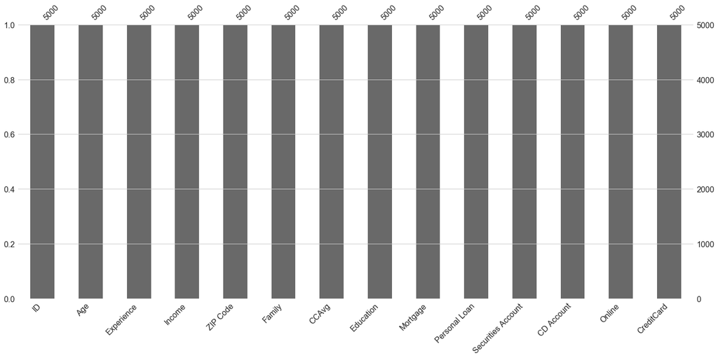

```python
msno.bar(data);
```

**Incorrect imputations**

We identified the column "Experience" with incorrect imputations since it shows negative values so we are now visualizing the column to analyze the distribution

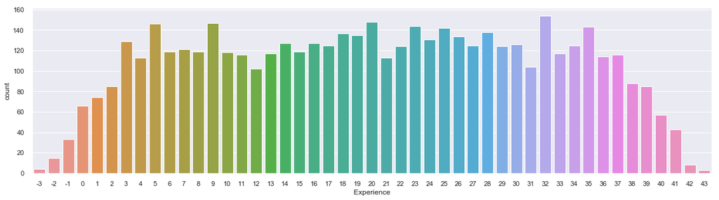

```python
plt.figure(figsize=(20,5))
sns.set(style="darkgrid")
ax = sns.countplot(x="Experience", data=data)
```

We use the mean of the experience column to replace all the negative values

```python
data['Experience'] = data['Experience'].replace([-1,-2,-3],20.10)
```

We can see now that "Experience" does not have any negative values

```python
data.describe().transpose().style.apply(lambda x: ['background: lightgreen' if x.name in ['Experience']
                              else '' for i in x], axis=1)
```

|  | count | mean | std | min | 25% | 50% | 75% | max |
| --- | --- | --- | --- | --- | --- | --- | --- | --- |
| ID | 5000 | 2500.5 | 1443.52 | 1 | 1250.75 | 2500.5 | 3750.25 | 5000 |
| Age | 5000 | 45.3384 | 11.4632 | 23 | 35 | 45 | 55 | 67 |
| Experience | 5000 | 20.3286 | 11.253 | 0 | 11 | 20.1 | 30 | 43 |
| Income | 5000 | 73.7742 | 46.0337 | 8 | 39 | 64 | 98 | 224 |
| ZIP Code | 5000 | 93152.5 | 2121.85 | 9307 | 91911 | 93437 | 94608 | 96651 |
| Family | 5000 | 2.3964 | 1.14766 | 1 | 1 | 2 | 3 | 4 |
| CCAvg | 5000 | 1.93794 | 1.74766 | 0 | 0.7 | 1.5 | 2.5 | 10 |
| Education | 5000 | 1.881 | 0.839869 | 1 | 1 | 2 | 3 | 3 |
| Mortgage | 5000 | 56.4988 | 101.714 | 0 | 0 | 0 | 101 | 635 |
| Personal Loan | 5000 | 0.096 | 0.294621 | 0 | 0 | 0 | 0 | 1 |
| Securities Account | 5000 | 0.1044 | 0.305809 | 0 | 0 | 0 | 0 | 1 |
| CD Account | 5000 | 0.0604 | 0.23825 | 0 | 0 | 0 | 0 | 1 |
| Online | 5000 | 0.5968 | 0.490589 | 0 | 0 | 1 | 1 | 1 |
| CreditCard | 5000 | 0.294 | 0.455637 | 0 | 0 | 0 | 1 | 1 |

**2.** EDA: Study the data distribution in each attribute and target variable, share your findings **(20 marks)**

```
* Number of unique in each column?
* Number of people with zero mortgage?
* Number of people with zero credit card spending per month?
* Value counts of all categorical columns.
* Univariate and Bivariate
* Get data model ready
```

**Identify uniques in each column**

```python
data.nunique()
```

```
ID                    5000
Age                     45
Experience              45
Income                 162
ZIP Code               467
Family                   4
CCAvg                  108
Education                3
Mortgage               347
Personal Loan            2
Securities Account       2
CD Account               2
Online                   2
CreditCard               2
dtype: int64
```

**Identify people with zero mortgage, credit card spending, and no credit**

```python
# Number of people with Zero mortgage
people_no_mortgage = data['Mortgage'][data['Mortgage'] == 0].count()

# Print totals and percentages
print (f'People with Zero Mortgage', people_no_mortgage)
print (f'Percentage of People with Zero Mortgage %', ((people_no_mortgage/len(data)*100)))
print()

# Number of people with zero credit card spending per month
people_no_credit = data['CCAvg'][data['CCAvg'] == 0].count()

# Print totals and percentages
print (f'People with Zero Credit', people_no_credit)
print (f'Percentage of People with Zero Credit %', ((people_no_credit/len(data)*100)))
```

```
People with Zero Mortgage 3462
Percentage of People with Zero Mortgage % 69.24

People with Zero Credit 106
Percentage of People with Zero Credit % 2.12
```

```python
data['Education'].value_counts()
```

```
1    2096
3    1501
2    1403
Name: Education, dtype: int64
```

**Univariate analysis**

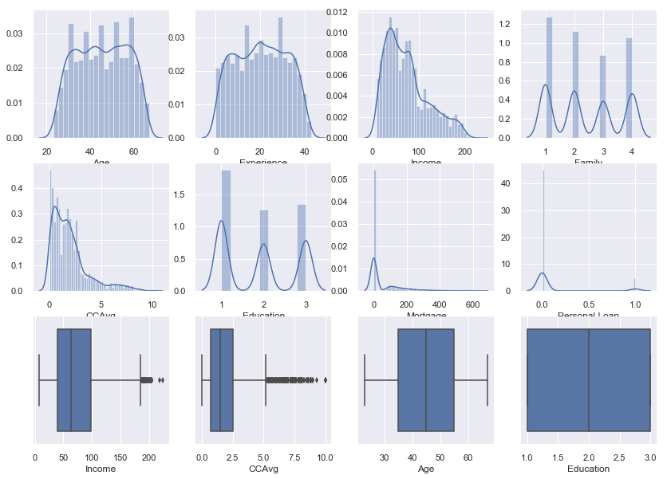

```python
# Set up the matplotlib figure
f, axes = plt.subplots(3,4, figsize=(14, 10))
sns.despine(left=True)

# Plot histogram and plot box for each variable that is relevant
sns.distplot(data['Age'],ax=axes[0,0]);
sns.distplot(data['Experience'],ax=axes[0,1]);
sns.distplot(data['Income'],ax=axes[0,2]);
sns.distplot(data['Family'],ax=axes[0,3]);
sns.distplot(data['CCAvg'],ax=axes[1,0]);
sns.distplot(data['Education'],ax=axes[1,1]);
sns.distplot(data['Mortgage'],ax=axes[1,2]);
sns.distplot(data['Personal Loan'],ax=axes[1,3]);
sns.boxplot(data['Income'],ax=axes[2,0]);
sns.boxplot(data['CCAvg'],ax=axes[2,1]);
sns.boxplot(data['Age'],ax=axes[2,2]);
sns.boxplot(data['Education'],ax=axes[2,3]);
```

**Bivariate analysis**

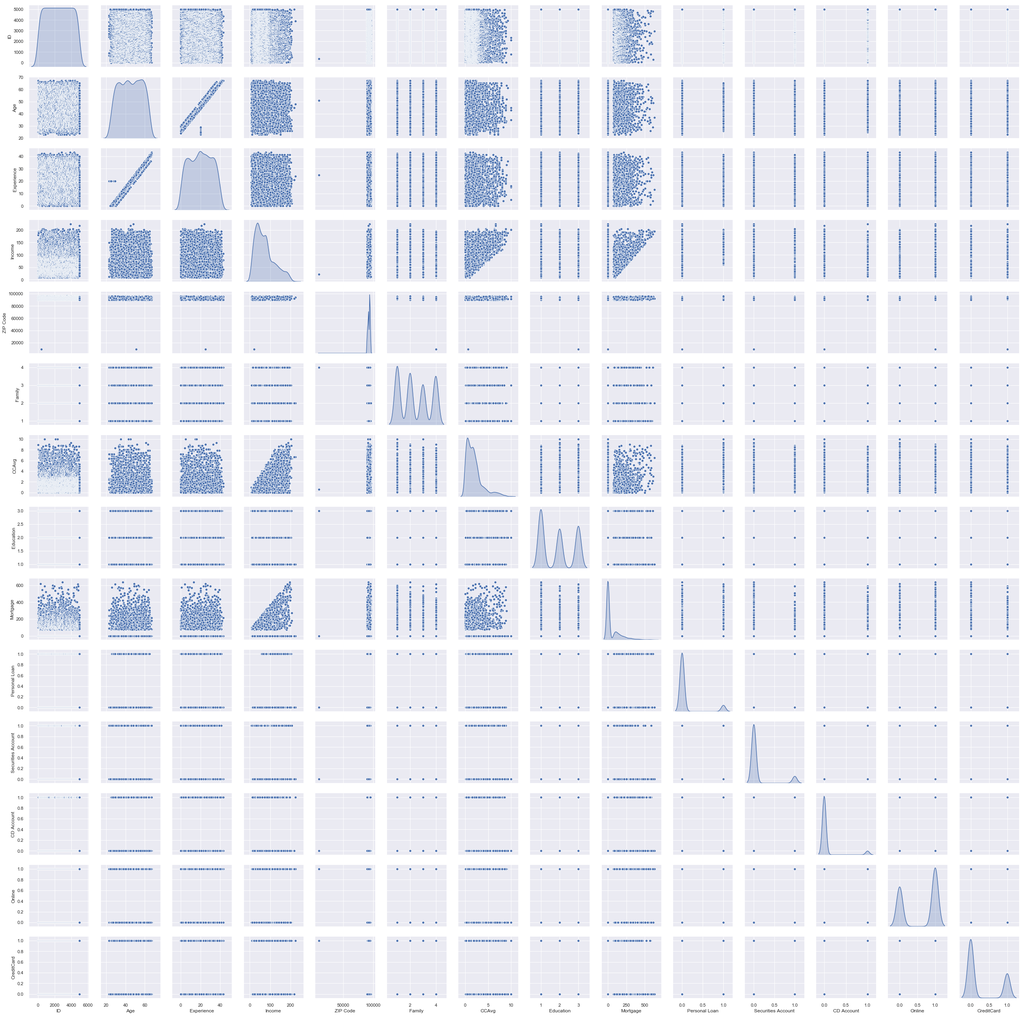

```python
sns.pairplot(data,diag_kind='kde');
```

**Correlation analysis**

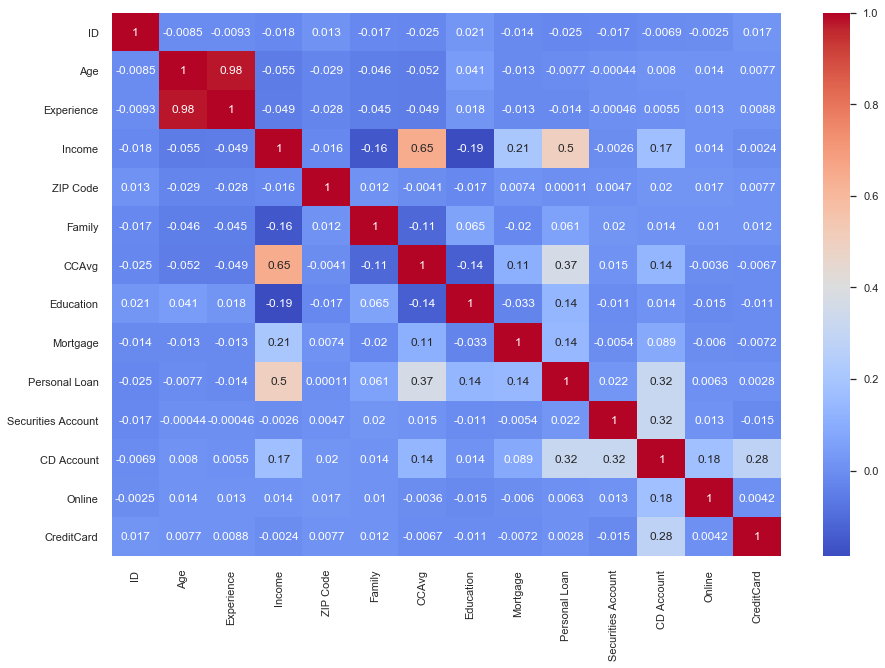

```python
# Set the figsize
fig, ax = plt.subplots(figsize=(15,10))

# Plot the heatmap
sns.heatmap(data.corr(), annot = True, cmap= 'coolwarm' );
```

```python
# Let us look at the target column
data.groupby(["Personal Loan"]).mean()
```

| Personal Loan | ID | Age | Experience | Income | ZIP Code | Family | CCAvg | Education | Mortgage | Securities Account | CD Account | Online | CreditCard |
| --- | --- | --- | --- | --- | --- | --- | --- | --- | --- | --- | --- | --- | --- |
| 0 | 2,512.17 | 45.37 | 20.38 | 66.24 | 93,152.43 | 2.37 | 1.73 | 1.84 | 51.79 | 0.10 | 0.04 | 0.60 | 0.29 |
| 1 | 2,390.65 | 45.07 | 19.84 | 144.75 | 93,153.20 | 2.61 | 3.91 | 2.23 | 100.85 | 0.12 | 0.29 | 0.61 | 0.30 |

**Get data model ready**

```python
# Drop the target colum from the x attributes
X = data.drop(['Personal Loan', "ID", "ZIP Code"],axis=1)     # Predictor feature columns
X = pd.get_dummies(X, drop_first=True)

# Create the target attribute
Y = data['Personal Loan']   # Predicted class (1=True, 0=False)
```

**3.** Split the data into training and test set in the ratio of 70:30 respectively **(5 marks)**

```python
# Split the data into train and test
x_train, x_test, y_train, y_test = train_test_split(X, Y, test_size=0.3, random_state=1)

# Print percentages of train and test data
print("{0:0.2f}% data is in training set".format((len(x_train)/len(data.index)) * 100))
print("{0:0.2f}% data is in test set".format((len(x_test)/len(data.index)) * 100))
print()

# Print original total values  for target variable in data set
print("Original Loans True Values    : {0} ({1:0.2f}%)".format(len(data.loc[data['Personal Loan'] == 1]), (len(data.loc[data['Personal Loan'] == 1])/len(data.index)) * 100))
print("Original Loans False Values   : {0} ({1:0.2f}%)".format(len(data.loc[data['Personal Loan'] == 0]), (len(data.loc[data['Personal Loan'] == 0])/len(data.index)) * 100))
print("")

# Print total values  for target variable in training data set
print("Training Loans True Values    : {0} ({1:0.2f}%)".format(len(y_train[y_train[:] == 1]), (len(y_train[y_train[:] == 1])/len(y_train)) * 100))
print("Training Loans False Values   : {0} ({1:0.2f}%)".format(len(y_train[y_train[:] == 0]), (len(y_train[y_train[:] == 0])/len(y_train)) * 100))
print("")

# Print total values  for target variable in test data set
print("Test Loans True Values        : {0} ({1:0.2f}%)".format(len(y_test[y_test[:] == 1]), (len(y_test[y_test[:] == 1])/len(y_test)) * 100))
print("Test Loans False Values       : {0} ({1:0.2f}%)".format(len(y_test[y_test[:] == 0]), (len(y_test[y_test[:] == 0])/len(y_test)) * 100))
print("")

# Print first five rows of training data
x_train.head()
```

```
70.00% data is in training set
30.00% data is in test set

Original Loans True Values    : 480 (9.60%)
Original Loans False Values   : 4520 (90.40%)

Training Loans True Values    : 331 (9.46%)
Training Loans False Values   : 3169 (90.54%)

Test Loans True Values        : 149 (9.93%)
Test Loans False Values       : 1351 (90.07%)
```

|  | Age | Experience | Income | Family | CCAvg | Education | Mortgage | Securities Account | CD Account | Online | CreditCard |
| --- | --- | --- | --- | --- | --- | --- | --- | --- | --- | --- | --- |
| 1334 | 47 | 22.00 | 35 | 2 | 1.30 | 1 | 0 | 0 | 0 | 1 | 0 |
| 4768 | 38 | 14.00 | 39 | 1 | 2.00 | 2 | 0 | 0 | 0 | 1 | 0 |
| 65 | 59 | 35.00 | 131 | 1 | 3.80 | 1 | 0 | 0 | 0 | 1 | 1 |
| 177 | 29 | 3.00 | 65 | 4 | 1.80 | 2 | 244 | 0 | 0 | 0 | 0 |
| 4489 | 39 | 13.00 | 21 | 3 | 0.20 | 2 | 0 | 0 | 0 | 1 | 0 |

**4.** Use Logistic Regression model to predict whether the customer will take personal loan or not. Print all the metrics related for evaluating the model performance **(15 marks)**

```python
# Fit the model on train
model = LogisticRegression(solver="liblinear")
model.fit(x_train, y_train)

# predict on test
y_predict = model.predict(x_test)

# Get the score
model_score = model.score(x_test, y_test)
print('accuracy %s' %(model_score))

# Run classification report
report = classification_report(y_test, y_predict)
print(report)
```

```
accuracy 0.942
              precision    recall  f1-score   support

           0       0.95      0.99      0.97      1351
           1       0.83      0.52      0.64       149

   micro avg       0.94      0.94      0.94      1500
   macro avg       0.89      0.76      0.81      1500
weighted avg       0.94      0.94      0.94      1500
```

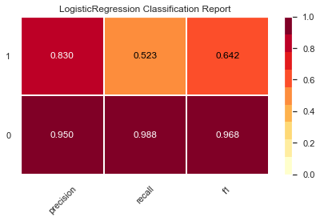

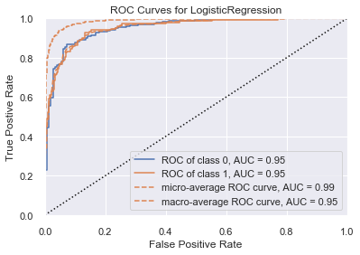

```python
# Visualize model performance with yellowbrick library
viz = ClassificationReport(model)
viz.fit(x_train, y_train)
viz.score(x_test, y_test)
viz.show()

roc = ROCAUC(model)
roc.fit(x_train, y_train)
roc.score(x_test, y_test)
roc.show();
```

```python
# model evaluation for testing set

mae = metrics.mean_absolute_error(y_test, y_predict)
mse = metrics.mean_squared_error(y_test, y_predict)
r2 = metrics.r2_score(y_test, y_predict)

print("The model performance for testing set")
print("--------------------------------------")
print('MAE is {}'.format(mae))
print('MSE is {}'.format(mse))
print('R2 score is {}'.format(r2))
```

```
The model performance for testing set
--------------------------------------
MAE is 0.058
MSE is 0.058
R2 score is 0.3517106393971159
```

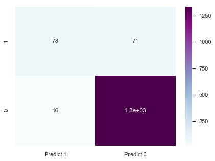

```python
# Create confusion matrix
cm=metrics.confusion_matrix(y_test, y_predict, labels=[1, 0])

df_cm = pd.DataFrame(cm, index = [i for i in ["1","0"]],
                  columns = [i for i in ["Predict 1","Predict 0"]])
plt.figure(figsize = (7,5))
sns.heatmap(df_cm, annot=True, cmap="BuPu");
```

**5.** Give your reasoning on how can the model perform better? **(10 marks)** Hint: Check parameter

**Visualize the model parameters and how they influence the results**

```python
# Create a list of original variable names from the training DataFrame
original_variables = x_train.columns

# Extract the coefficients of the logistic regression estimator
model_coefficients = model.coef_[0]

# Create a dataframe of the variables and coefficients & print it out
coefficient_df = pd.DataFrame({"Variable" : original_variables, "Coefficient": model_coefficients})
coefficient_df
```

|  | Variable | Coefficient |
| --- | --- | --- |
| 0 | Age | -0.09 |
| 1 | Experience | 0.08 |
| 2 | Income | 0.04 |
| 3 | Family | 0.49 |
| 4 | CCAvg | 0.14 |
| 5 | Education | 1.27 |
| 6 | Mortgage | 0.00 |
| 7 | Securities Account | -0.94 |
| 8 | CD Account | 3.24 |
| 9 | Online | -0.62 |
| 10 | CreditCard | -1.05 |

```python
# Print out the top 3 positive variables
top_three_df = coefficient_df.sort_values(by='Coefficient', axis=0, ascending=False)[0:3]
top_three_df
```

|  | Variable | Coefficient |
| --- | --- | --- |
| 8 | CD Account | 3.24 |
| 5 | Education | 1.27 |
| 3 | Family | 0.49 |

**Analyze the model hyper parameters**

```python
# Visualize model hyper parameters
print(model)
```

```
LogisticRegression(C=1.0, class_weight=None, dual=False, fit_intercept=True,
          intercept_scaling=1, max_iter=100, multi_class='warn',
          n_jobs=None, penalty='l2', random_state=None, solver='liblinear',
          tol=0.0001, verbose=0, warm_start=False)
```

We will use GridSearchCV to fine tune the hyper parameters, using all the solvers and adding 10 folds on each search

```python
# Define penalty
penalty = ['l1', 'l2']
penalty_1 = ['l2']

#Define C, class_weight and solver
C = [0.0001, 0.001, 0.01, 0.1, 1, 10, 100, 1000]
class_weight = [{1:0.5, 0:0.5}, {1:0.4, 0:0.6}, {1:0.6, 0:0.4}, {1:0.7, 0:0.3}]
solver = ['liblinear', 'saga']
solver_1 = ['newton-cg', 'saga','lbfgs']

# Create the dictionary with the params
param_grid = dict(penalty=penalty,C=C,class_weight=class_weight,solver=solver)
param_grid_1 = dict(penalty=penalty_1,C=C,class_weight=class_weight,solver=solver_1)

# Create the Grid object
grid = GridSearchCV(estimator=model,param_grid=param_grid,scoring='roc_auc',verbose=1,cv=10,n_jobs=-1)
grid_1 = GridSearchCV(estimator=model,param_grid=param_grid_1,scoring='roc_auc',verbose=1,cv=10,n_jobs=-1)

# Fir the object
grid_result = grid.fit(x_train, y_train)
grid_result_1 = grid_1.fit(x_train, y_train)

# Print results
print('Best Score liblinear and saga: ', grid_result.best_score_)
print('Best Params liblinear and saga: ', grid_result.best_params_)

print('Best Score newton-cg and lbfgs: ', grid_result_1.best_score_)
print('Best Params newton-cg and lbfgs: ', grid_result_1.best_params_)
```

```
Fitting 10 folds for each of 128 candidates, totalling 1280 fits
```

```
[Parallel(n_jobs=-1)]: Using backend LokyBackend with 12 concurrent workers.
[Parallel(n_jobs=-1)]: Done  26 tasks      | elapsed:    2.4s
[Parallel(n_jobs=-1)]: Done 767 tasks      | elapsed:    8.5s
[Parallel(n_jobs=-1)]: Done 1280 out of 1280 | elapsed:   15.4s finished
```

```
Fitting 10 folds for each of 96 candidates, totalling 960 fits
```

```
[Parallel(n_jobs=-1)]: Using backend LokyBackend with 12 concurrent workers.
[Parallel(n_jobs=-1)]: Done  28 tasks      | elapsed:    0.4s
[Parallel(n_jobs=-1)]: Done 328 tasks      | elapsed:    4.2s
[Parallel(n_jobs=-1)]: Done 828 tasks      | elapsed:   12.2s
```

```
Best Score liblinear and saga:  0.9620384695187023
Best Params liblinear and saga:  {'C': 10, 'class_weight': {1: 0.7, 0: 0.3}, 'penalty': 'l1', 'solver': 'liblinear'}
Best Score newton-cg and lbfgs:  0.961980867534782
Best Params newton-cg and lbfgs:  {'C': 1000, 'class_weight': {1: 0.7, 0: 0.3}, 'penalty': 'l2', 'solver': 'newton-cg'}
```

```
[Parallel(n_jobs=-1)]: Done 960 out of 960 | elapsed:   14.1s finished
```

The results from the GridSearch show that the best parameters for the model are:

```python
print(f'C = ',grid_result.best_params_['C'])
print(f'class_weight = ',grid_result.best_params_['class_weight'])
print(f'penalty = ',grid_result.best_params_['penalty'])
print(f'solver = ',grid_result.best_params_['solver'])
```

```
C =  10
class_weight =  {1: 0.7, 0: 0.3}
penalty =  l1
solver =  liblinear
```

```python
# predict on test
y_predict = grid_result.predict(x_test)

# Get the score
model_score = grid_result.score(x_test, y_test)
print('accuracy %s' %(model_score))

# Run classification report
report = classification_report(y_test, y_predict)
print(report)
```

```
accuracy 0.9532089081416203
              precision    recall  f1-score   support

           0       0.97      0.97      0.97      1351
           1       0.69      0.69      0.69       149

   micro avg       0.94      0.94      0.94      1500
   macro avg       0.83      0.83      0.83      1500
weighted avg       0.94      0.94      0.94      1500
```

```python
solver_list = ['newton-cg', 'lbfgs', 'sag', 'saga']
params = dict(solver=solver_list)
log_reg = LogisticRegression(C=1, n_jobs=-1, random_state=34, max_iter=5000)
clf = GridSearchCV(log_reg, params, cv=10)
clf.fit(x_train, y_train)
scores = clf.cv_results_['mean_test_score']

for score, solver in zip(scores, solver_list):
    print(f"  {solver} {score:.3f}" )
```

```
  newton-cg 0.951
  lbfgs 0.951
  sag 0.924
  saga 0.921
```

After fidning that newton-cg is the model that perform best, we run again our train model and can see the improvent in precision for customer that would accept a loan

```python
# Fit the model on train
log_reg = LogisticRegression(solver="newton-cg")
log_reg.fit(x_train, y_train)

# predict on test
y_predict = log_reg.predict(x_test)

# Get the score
model_score = log_reg.score(x_test, y_test)
print('accuracy %s' %(model_score))

# Run classification report
report = classification_report(y_test, y_predict)
print(report)
```

```
accuracy 0.9486666666666667
              precision    recall  f1-score   support

           0       0.95      0.99      0.97      1351
           1       0.86      0.58      0.69       149

   micro avg       0.95      0.95      0.95      1500
   macro avg       0.91      0.78      0.83      1500
weighted avg       0.95      0.95      0.94      1500
```

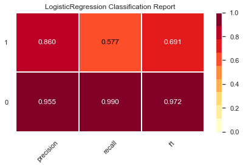

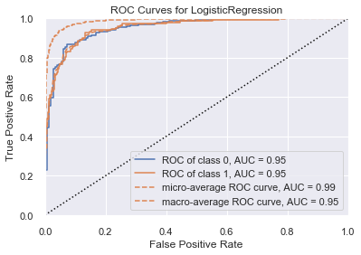

```python
# Visualize model performance with yellowbrick library
viz = ClassificationReport(log_reg)
viz.fit(x_train, y_train)
viz.score(x_test, y_test)
viz.show()

roc = ROCAUC(model)
roc.fit(x_train, y_train)
roc.score(x_test, y_test)
roc.show();
```

**6.** Give Business understanding of your model? **(5 marks)** Hint: Check parameter

**Business understanding:** **Confusion matrix means:** *True Positive (observed=1,predicted=1):* Predicted that a loan was offered and the customer will accept it and the customer accepted it *False Positive (observed=0,predicted=1):* Predicted that a loan was offered and the customer will accept it and the customer did not accept it *True Negative (observed=0,predicted=0):* Predicted that a loan was offered and the customer will not accept it and the customer did not accept it *False Negative (observed=1,predicted=0):* Predicted that a loan was offered and the customer will not accept it and the customer accept it Tha bank wants to determine what customers will accept a loan when it is offered, and the model shows a .86 accuracy for the True positives, not a bad number, but can be improved by balancing the data. The model shows 95% accuracy for those customers that will not accept a loan if they were offered, but for this analysis that is irrelevant since the bank wants to identify those who would accept. The results of the ML model show 86% accuracy on predicting that a customer will accept a loan in this second round after tunning the parameters provided in the data, but as a consultant, I would still hold my report to the business owner just yet since I would like to still explore the other options to try to improve the model. The imbalanced data needs to be addressed so we can run a better model and predict more accurately the customers that will take a loan, which at the end of the day is the problem that we are trying to solve. The data also shows that Customers with a CD account are most likely to accept a loan, but they are about 6% of the total, so a strategy could be to work on having more candidates having CD accounts to improve the results.